# Example - Epigenetic Differential Expression, Preprocessing

Brett Maroni-Rana

```r
# set working directory
#setwd(dirname(rstudioapi::getActiveDocumentContext()$path))
```

## Introduction

This report is a preliminary analysis of Barrett’s esophagus (BE) methylation data. It compares two groups, BE that does not develop into cancer and one that does. More specifically, non-dysplastic Barrett’s (NDBE) and Barrett’s samples before the patient developed esophageal adenocarcinoma (EAC). In this way, a comparison of a low risk group (NDBE) can be made to a high risk group (EAC). Differentially methylated probe analysis is performed.

Here, preprocessing of the data takes place. In short, **minfi** is used to load raw .idat, three different normalization processes were used and compared and finaly, data was filtered using a number of criteria. More information of the preprocessing can be found below.

### Methylation Analysis Workflow

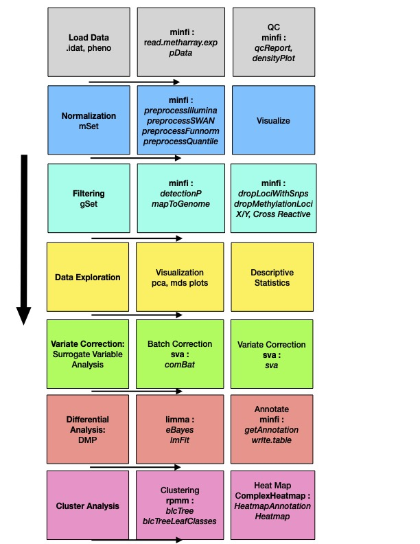

figure 1. dmp work-flow

## Load Data

Raw data can be found here:

- /pathA/pathB/pathC/ImageData
- /pathX/pathY/pathZ/ImageData

[output not shown]

[output not shown]

```r
# raw .idat dimensions
cat("Raw .idat Dimensions:",\n,dim(rg2))
```

[output not shown]

### Read Phenotypic Data

**Subset Samples**  
There are a total of 21 samples of interest. The sample sheets will be subsetted according to the sample of interest “sample” number. Once subsetted, the rg set can be subset accordingly

```r
# preview data
ssheet2$sample
cat("Sample Sheet Dimensions:",\n,dim(ssheet2))
ssheet2
```

[output not shown]

Perhaps the same array was ran twice? OR all samples were ran through the software to “harmonize” all previous samples. All information is the same except the batch name format. For example, instead of May2012, it reads 12-May.

Will move forward with only data from rg2 and experiment titled: **“Example_Experiment_Name”**

**Subset rgSet according to Samlpe Sheet**

```r
# subset rg2 according to sample sheets
rg2 <- rg2[,sampleNames(rg2) %in% ssheet2$sampleNames]
dim(rg2) # 622399     21
sampleNames(rg2)
```

**Add Pheno Data + “Risk”**

Additional phenotypic data includes age, sex and batch of samples. Importantly, “risk” must be added to the pheno data according to samples of interest. The data is cleaned and harmonized before being added to the rgSet object.

```r
# preview data
table(pheno$sample, pheno$risk)
```

[output not shown]

**Write to .csv**

A .csv containing pheno data in this experiment is written to file.

See: **example_pheno_data.csv**

Pheno data is written to file and added to rgSet object. QC, Normalization and Filtering is ran next.  
*pheno data is not written in this example report*

### Quality Control

See : ‘qc_raw_report.pdf’ for a detailed QC report

```r
# QC sample and density plot
mSet_raw <- preprocessRaw(rg2)
qc <- getQC(mSet_raw)
pdf('qc_raw_samples.pdf', height = 5, width = 10)
par(mfrow=c(1,2))
plotQC(qc)
dev.off()
plotQC(qc)
```

[output not shown]

## Normalization

Illumina methylation array technology has evoloved over time and incorporates two different types of probes into their Array system. Accounting for these technical differes is an important step in methylation analysis using Illumina Arrays. Therfore, probe normalization is performed with three methods and density plots created for each. More info on each normalization process is below.

### SWAN Normalization

**Subset-quantile Within Array Normalization (SWAN) : preprocessSWAN()**

- Matches beta distributions of the Type I to Type II probes by applying a within-array quantile normalization separately for different subsets of probes.
- Input = rgSet or mSet, output = mSet

```r
# Illumina and SWAN normalization and plot
datIlmn <- preprocessIllumina(rg2)
mSet_swan <- preprocessSWAN(rg2, mSet = datIlmn) # output = MethylSet
pdf('qc_swan_norm.pdf', height = 5, width = 10)
par(mfrow=c(1,2))
densityPlot(mSet_swan, main = "SWAN Normalized Density Plot")
dev.off()
densityPlot(mSet_swan, main = "SWAN Normalized Density Plot")
```

[output not shown]

**Functional Normalization : preprocesesFunnorm()**

- Uses internal control probes to infer between-array technical variation by using the first two principal components of the control probes
- Recommended for samples with vast global differences, cancer/control
- Input = RGChannelSet, output = GenomicRatioSet
- Ready for down-stream analysis following normalization

```r
# Functional Normalization
# works well for cancer/normal
# samples in which are vastly different
gRSet_fun <- preprocessFunnorm(rg2) # output = GenomicRatioSet
densityPlot(getBeta(gRSet_fun), sampGroups=pheno$risk,
            main="Functional Normalized", legend=FALSE)
legend("top", legend = levels(factor(pheno$risk)),
       text.col=brewer.pal(8,"Dark2"))
```

[output not shown]

**Stratified Quantile Normalization : preprocessesQuantile()**

- Type II probes are quantile normalized across samples, then Type I probes are interpolated (estimated) to this reference distribution
- Stratified normalization of meth and unmeth intensities (done separately)
- Recommended for samples with subtle differences, possibly sub-typing
- Input = RGChannelSet, output = GenomicRatioSet
- Ready for down-stream analysis following normalization

```r
# Quantile Normalization
# works well for samples with subtle differences
# not so well for samples that are vastly different
gRSet_quant <- preprocessQuantile(rg2) # output = GenomicRatioSet
densityPlot(getBeta(gRSet_quant), sampGroups=pheno$risk,
            main="Quantile Normalized", legend=FALSE)
legend("top", legend = levels(factor(pheno$risk)),
       text.col=brewer.pal(8,"Dark2"))
```

[output not shown]

### Filtering

Filtering is performed by a number of methods. They are found below:

**Poor Performing Probes : detP()**

- Compares probe status with negative control and runs statistical test
- P-value > 0.01 in more than 10% of samples is removed

**SNPs : dropLociWithSnps(), dropMethylationLoci()**

- SNP association with CpG sites causes variability and should be removed

**X / Y :** Gender related probes used for QC are removed

**Cross Reactive Probes :**

- Two papers outline cross reactive probes. These probes are removed depending on 450K or EPIC array
- Chen et al 2013 (HM450 platform), and Pidsley et al 2016 (EPIC platform).